# 状態空間モデルによるデータの季節調整

SeiTAKANE

2022-12-24

## セットアップと季節調整の概要

- 使用パッケージ

```r
pacman::p_load(rstan, #stanとの連携用
               bayesplot,#収束の可視化
               ggfortify,#時系列分析用
               tidyverse #データ整形、可視化
               )
```

- 使用データ
  - 使用するデータ: 2002年10月から2017年3月までの月ごとの米国の国際線旅客数
  - データ引用元: [米国交通統計局](https://www.transtats.bts.gov/Data_Elements.aspx)

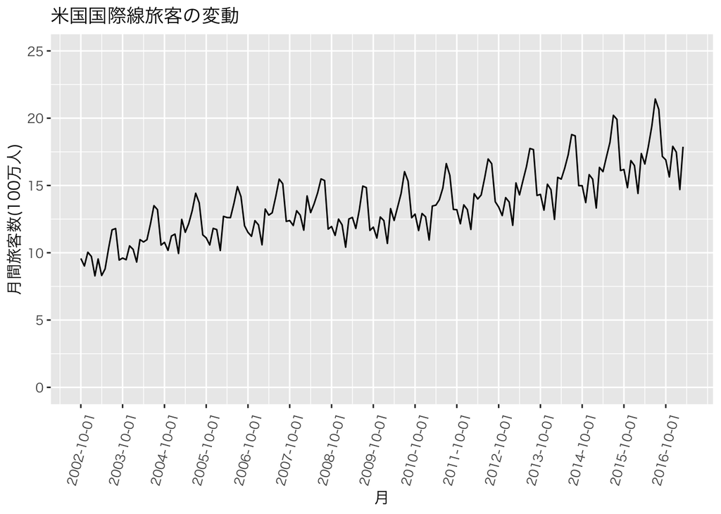

```r
#データセットの読み込み（今回は同一dirにデータを配置）
pax <- read.csv("all_airlines_all_airports.csv")

#時間を表す列をdate型に変更
pax$Date <- as.Date(pax$Date)

#分析のために変数名などを変更して、単位を100万単位にならしておく
pax_int <- tibble(month =as.POSIXct(pax$Date),
      pax_int =pax$Passengers_International/1000000)

#可視化で大枠の確認
pax  %>%
  ggplot()+
  geom_line(aes(x = as.Date(Date),y =Passengers_International/1000000))+
  scale_y_continuous(limits = c(0,25))+
  scale_x_continuous(breaks = seq(min(pax$Date),max(pax$Date),by ="year"))+
  labs(x = "月",y = "月間旅客数(100万人)",title = "米国国際線旅客の変動")+
  theme_gray (base_family = "HiraKakuPro-W3")+#mac使用のためフォント指定
  theme(axis.text.x = element_text(angle = 75, vjust = 0.5))
```

$$\begin{aligned}
\mu_t & \sim \text{Normal} (2 \mu_{t-1} - \mu_{t-2},
\sigma^2_{\xi}), \\
\gamma_t & \sim \text{Normal} (- \sum_{t-11}^{t-1} \gamma_i,
\sigma^2_{s}), \\
\alpha_t & = \mu_t + \gamma_t , \\
y_t & \sim \text{Normal} (\alpha_t, \sigma^2_{v})
\end{aligned}$$

## 実装

- 移動平均法による季節調整
  - 比較としてまずは、移動平均法(12ヶ月)を行っておく

```r
mv_12 <- c()
for(i in 1:(length(pax_int$pax_int)-11)){
  start <- i
  end <- i+11
  mv_12[i] <- sum(pax_int$pax_int[start:end])/12
}
pax_int$mv_12 <- NA
pax_int$mv_12[12:length(pax_int$pax_int)] <- mv_12
```

- 状態空間モデルの実装（処理内容は”seasonal_adj.stan”を参照）

```r
#データのリスト格納
data_list <- list(
  y = pax_int$pax_int,
  T = nrow(pax_int)
)

#モデルの実装
#計算の高速化のため
rstan_options(auto_write = TRUE)
options(mc.cores = parallel::detectCores())

#stanの実行
pax_seasonal_adj <- stan(
  file = "seasonal_adj.stan", #処理をさせるstan_file
  data = data_list, #データ
  seed = 1,#乱数の種
  chains = 4, #チェーン数
  thin = 6, #間引き数
  iter = 8000, #乱数の繰り返し回数
  warmup = 5000, #バーンイン回数
  control = list(adapt_delta = 0.98, max_treedepth = 15)#事後分布の受け入れ確率、勾配の評価回数の再設定
)
```

- モデル実装結果の確認

```r
#mcmcサンプルの取得
print(pax_seasonal_adj,
      par = c("s_z","s_s","s_v","lp__"),
      probs = c(0.025,0.5,0.975))
```

```
## Inference for Stan model: seasonal_adj.
## 4 chains, each with iter=8000; warmup=5000; thin=6;
## post-warmup draws per chain=500, total post-warmup draws=2000.
##
##        mean se_mean    sd   2.5%    50%  97.5% n_eff Rhat
## s_z    0.11    0.00  0.02   0.07   0.11   0.16   381 1.01
## s_s    0.11    0.00  0.03   0.06   0.10   0.18   239 1.02
## s_v    0.16    0.00  0.03   0.08   0.16   0.22   287 1.02
## lp__ 810.56    1.23 30.06 757.09 808.70 875.49   597 1.01
##
## Samples were drawn using NUTS(diag_e) at Sat Dec 24 13:55:24 2022.
## For each parameter, n_eff is a crude measure of effective sample size,
## and Rhat is the potential scale reduction factor on split chains (at
## convergence, Rhat=1).
```

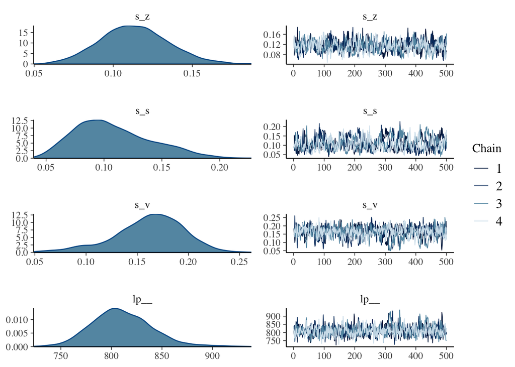

```r
mcmc_sample　<- rstan::extract(pax_seasonal_adj)
#収束の確認
mcmc_combo(pax_seasonal_adj, pars = c("s_z","s_s","s_v","lp__"))
```

-結果の可視化

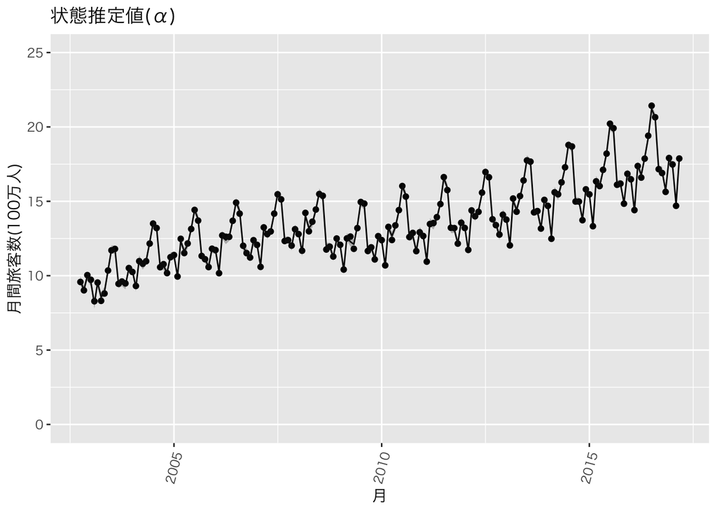

```r
#状態推定値(季節性+)の抜き出し
result_df_alpha <- data.frame(t(apply(
  X = mcmc_sample[["alpha"]],
  MARGIN = 2,
  FUN = quantile,
  probs = c(0.025,0.5,0.975)
)))

#カラム名の変更
colnames(result_df_alpha) <- c("alpha_lwr","alpha","alpha_upr")

#実測値の代入
result_df_alpha$month <- pax_int$month
result_df_alpha$obs <- pax_int$pax_int

#移動平均法での季節調整の結果
result_df_alpha$mv_12 <- pax_int$mv_12


#トレンド成分の抜き出し
result_df_mu <- data.frame(t(apply(
  X = mcmc_sample[["mu"]],
  MARGIN = 2,
  FUN = quantile,
  probs = c(0.025,0.5,0.975)
)))

#カラム名の変更
colnames(result_df_mu) <- c("mu_lwr","mu","mu_upr")

#実測値
result_df_mu$month <- pax_int$month


#季節性成分の抜き出し
result_df_gamma <- data.frame(t(apply(
  X = mcmc_sample[["gamma"]],
  MARGIN = 2,
  FUN = quantile,
  probs = c(0.025,0.5,0.975)
)))

#カラム名の変更
colnames(result_df_gamma) <- c("gamma_lwr","gamma","gamma_upr")

#実測値の代入
result_df_gamma$month <- pax_int$month

#結合
result_df <- left_join(result_df_alpha,result_df_mu,  by = "month")
result_df <- left_join(result_df,result_df_gamma, by= "month")

#状態推定値
alpha <- result_df %>% ggplot()+
  geom_point(aes(x = month, y= obs))+
  geom_line(aes(x = month, y= alpha))+
  geom_ribbon(aes(x = month, y= alpha,
                  ymin = alpha_lwr,ymax=alpha_upr),alpha = 0.3)+
  scale_y_continuous(limits = c(0,25))+
  labs(x = "月",y = "月間旅客数(100万人)",title = "状態推定値(α)")+
  theme_gray (base_family = "HiraKakuPro-W3")+#mac使用のためフォント指定
  theme(axis.text.x = element_text(angle = 75, vjust = 0.5))
plot(alpha)
```

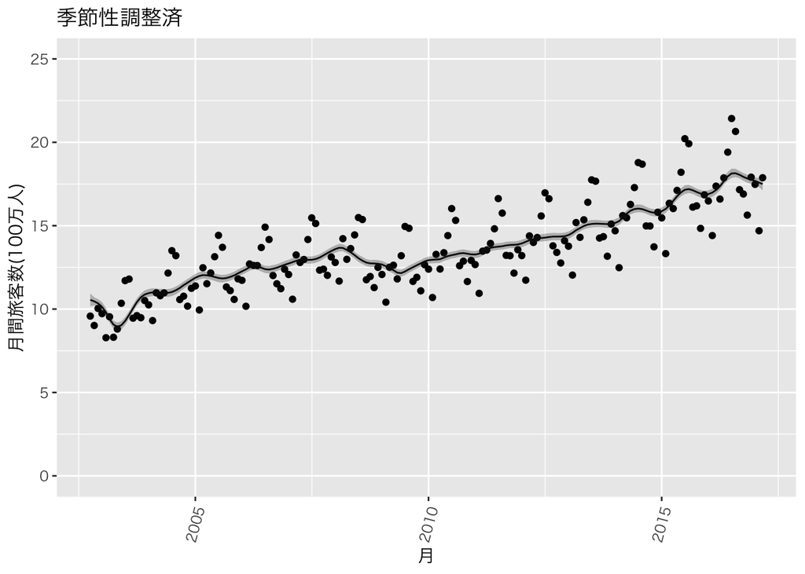

```r
#トレンド成分(季節調整値)
mu <- result_df %>% ggplot()+
  geom_point(aes(x = month, y= obs))+
  geom_line(aes(x = month, y= mu))+
  geom_ribbon(aes(x = month, y= mu,
                  ymin = mu_lwr,ymax=mu_upr),alpha = 0.3)+
  labs(title = "",y = "y",x="t")+
  scale_y_continuous(limits = c(0,25))+
  labs(x = "月",y = "月間旅客数(100万人)",title = "季節性調整済")+
  theme_gray (base_family = "HiraKakuPro-W3")+#mac使用のためフォント指定
  theme(axis.text.x = element_text(angle = 75, vjust = 0.5))

plot(mu)
```

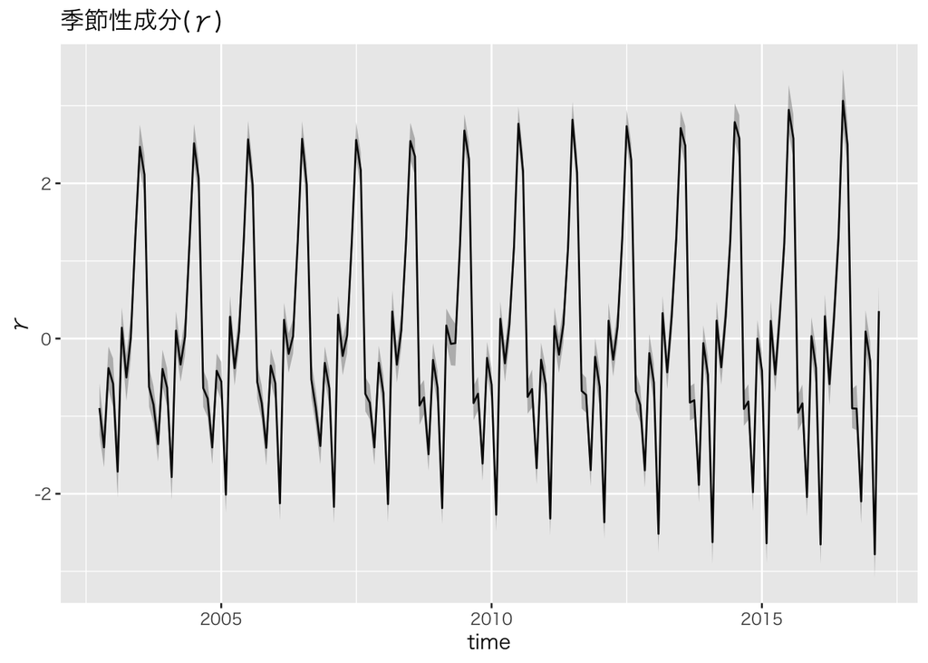

```r
#季節性成分の抽出
gamma <- result_df %>% ggplot()+
  geom_line(aes(x = month, y= gamma))+
  geom_ribbon(aes(x = month, y= gamma,
                  ymin = gamma_lwr,ymax=gamma_upr),alpha = 0.3)+
  labs(y = "γ",x="time",title = "季節性成分(γ)")+
  theme_gray (base_family = "HiraKakuPro-W3")

plot(gamma)
```

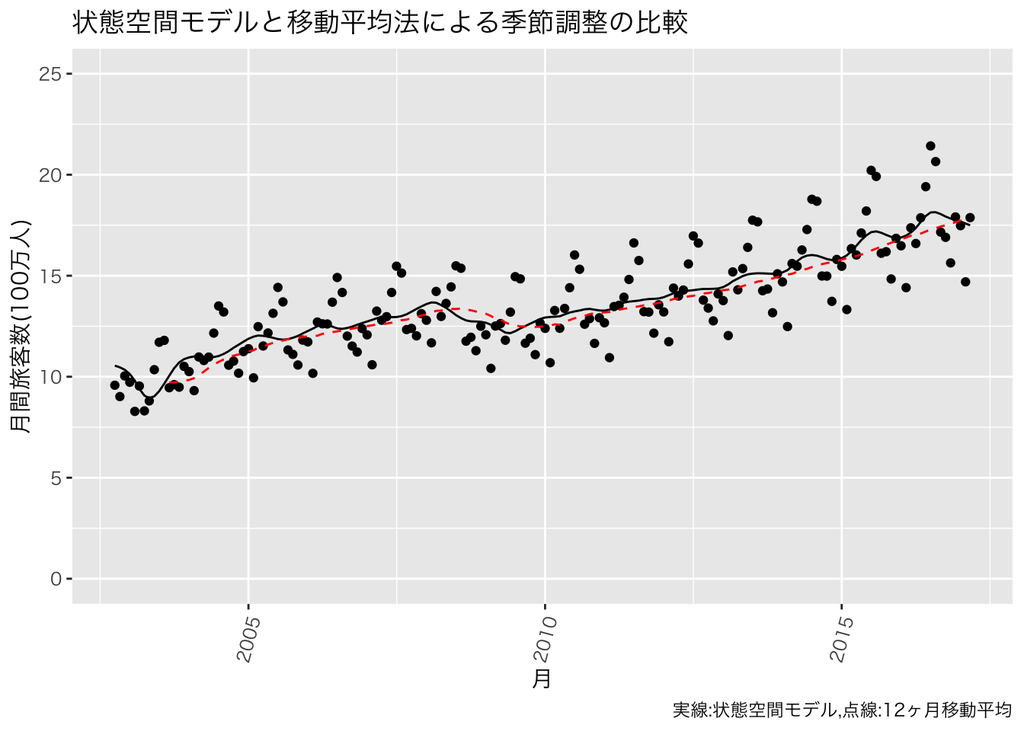

```r
#12ヶ月移動平均との比較
compara <- result_df %>% ggplot()+
  geom_point(aes(x = month, y= obs))+
  geom_line(aes(x = month, y= mu))+
  geom_line(aes(x = month, y= mv_12),linetype = 2,color = "red")+
  scale_y_continuous(limits = c(0,25))+
  labs(title = "状態空間モデルと移動平均法による季節調整の比較",y = "月間旅客数(100万人)",x="月",caption = "実線:状態空間モデル,点線:12ヶ月移動平均")+
  theme_gray (base_family = "HiraKakuPro-W3")+#mac使用のためフォント指定
  theme(axis.text.x = element_text(angle = 75, vjust = 0.5))

plot(compara)
```

- 参考
  - [実践Data Scienceシリーズ RとStanではじめる ベイズ統計モデリングによるデータ分析入門 (KS情報科学専門書)](https://www.kspub.co.jp/book/detail/5165362.html)
  - [RStan: the R interface to Stan](https://cran.r-project.org/web/packages/rstan/vignettes/rstan.html)
  - [米国交通統計局](https://www.transtats.bts.gov/Data_Elements.aspx)